# 23andMe Imputation QC

Robert Steinfelder

2025-05-08

## Impact of Missingness on Single Sample Imputated Direct To Consumer Genotyping Data

### PCA plot with 1000 Genomes

First 2 PCs of imputed VCF files were plotted with 1000Genomes cohort to check population structure, detect potential outliers and to see if there are potential issues with imputation.

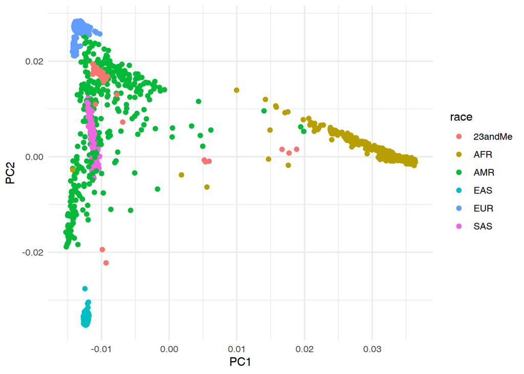

```r
library(ggplot2)
sf = read.table("/fh/fast/peters_u/GECCO_Working/robert_working/Projects/Webtool_PRS/Test/calibrate/PRS_Summary_from_Prototype_w_for_validation_adjusted_wPCs_Apr28_2025.tsv", header=T, sep='\t')

pc1kg = read.table("/fh/fast/peters_u/GECCO_Working/mintaworking/RS_Project/pcs_1000G/1000G_PCA.txt",
        header=T, sep='\t')
pcp = data.frame(PC1=c(pc1kg$PC1, sf$PC1),
                 PC2=c(pc1kg$PC2, sf$PC2),
                 race=c(pc1kg$race, rep("23andMe", nrow(sf))))
ggplot(pcp, aes(x=PC1, y=PC2, color=race)) + geom_point() + theme_minimal()
```

The plot shows no clear outliers, however, it’s surprising that no samples cluster with white/EUR. They are all in the admixed american (AMR/Latino) samples. This could indicate a bias introduced from single sample imputation.

### Missingness and Imputation $Rsq$

Next, we check for missingness in each sample and if there is an affect on $Rsq$.

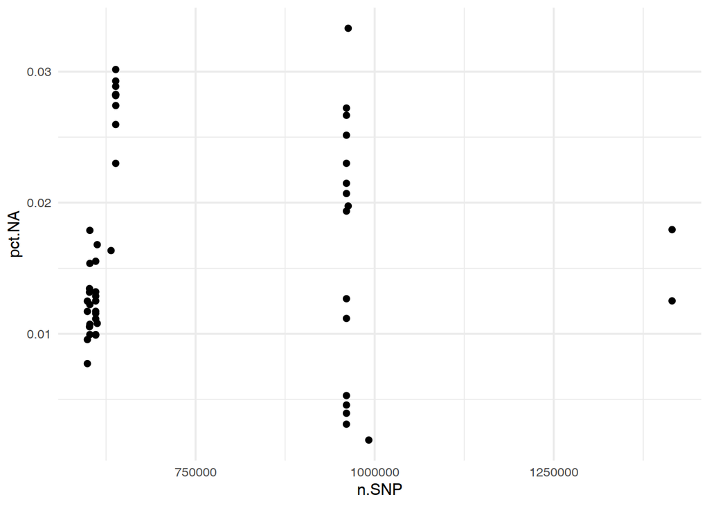

```r
results = read.table("/fh/fast/peters_u/GECCO_Working/robert_working/nextflow/FH-PRS-tool-example/inputQC/23andMe_imputation_stats_Apr28_2025.tsv", header=T,
                     sep='\t')
ggplot(results, aes(x=n.SNP, y=pct.NA)) + geom_point() + theme_minimal()
```

```r
results$chip = ifelse(results$n.SNP < 750000, "600k", ifelse(results$n.SNP < 1000000, "950k", "1.3m"))
table(results$chip)
```

```
##
## 1.3m 600k 950k
##    2   33   16
```

Let’s compare percent missingness to mean $Rsq$:

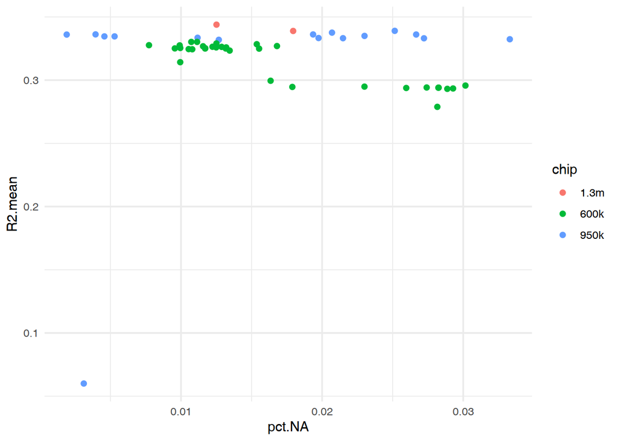

```r
p = ggplot(results, aes(x=pct.NA, y=R2.mean, color=chip)) + geom_point() + theme_minimal()
plot(p)
```

- Missingness of > 1.5% does seem to have an impact on samples genotyped on small chips (600k SNPs).
- There is also one sample with low missingness (< 1%) but a much lower $Rsq$ (< 0.1). The sample (FID: genome_23-And-Me) should be further investigated and is a candidate to drop.

Next, we check if missingness or $Rsq$ has an impact on PRS.

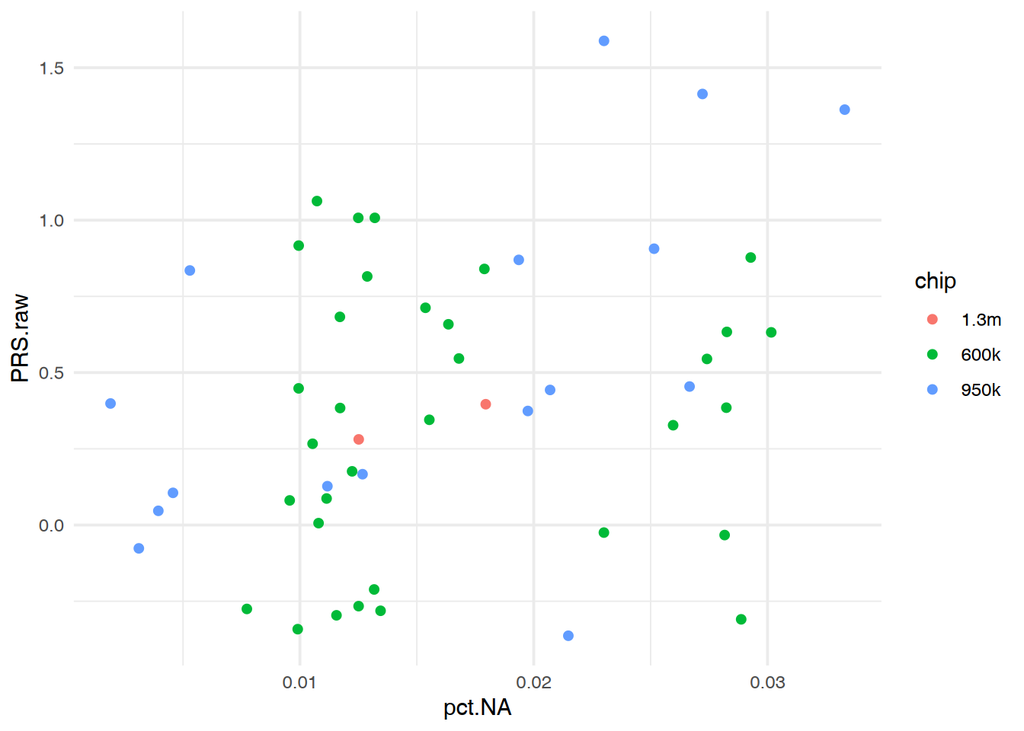

```r
p = ggplot(results, aes(x=pct.NA, y=PRS.raw, color=chip)) + geom_point() + theme_minimal()
plot(p)
```

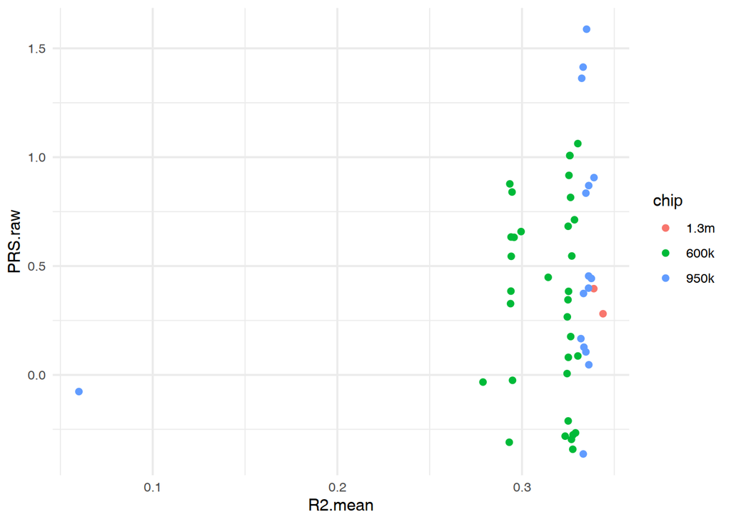

```r
p = ggplot(results, aes(x=R2.mean, y=PRS.raw, color=chip)) + geom_point() + theme_minimal()
plot(p)
```

Neither percent missingness or mean $Rsq$ correlate with PRS. However, PRS could still be biased (e.g., towards the population mean), which wouldn’t be observed here.

Imputation $Rsq$ is defined as:

$Rsq = \frac{Var(posterior\ dosage)}{Var(true\ genotypes)}$

The denominator is usually estimated from the imputed cohort [Binary Dosage] (https://cran.r-project.org/web/packages/BinaryDosage/vignettes/r2estimates.html). In single sample imputation, though, it is estimated from the reference population -in our case, the 1000 genomes cohort. For monomorphic SNPs or SNPs with low MAF this could lead to problems, since the denominator can get very small causing unstable $Rsq$.

### Imputation $Rsq$ and MAF

To visualize this, let’s plot MAF vs $Rsq$ for chr1 of sample 912014genome_Full_20140901163652:

```r
library(vcfR)
```

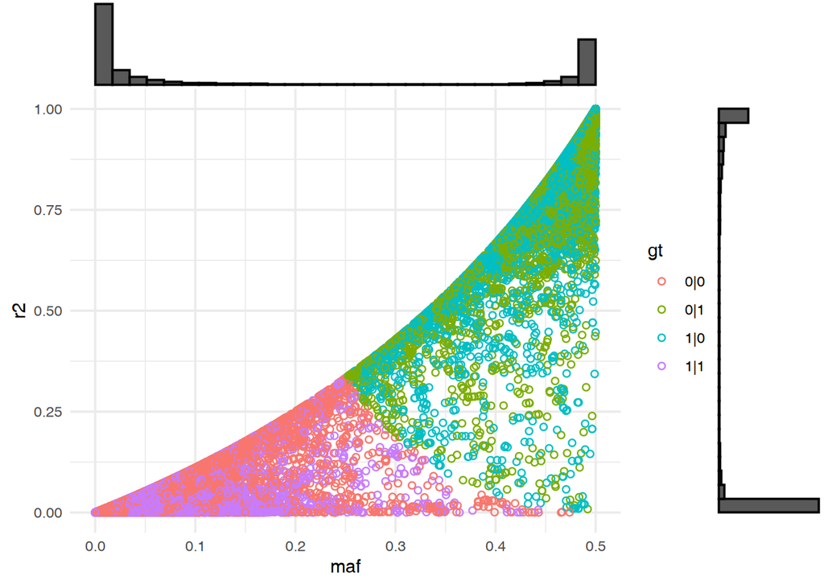

```r
library(ggExtra)
makeMutID <- function(vcf){
        if(nrow(vcf@fix) > 1){
                return(paste(paste(apply(vcf@fix[,c("CHROM", "POS")], MARGIN=1, paste, collapse=":"),
                vcf@fix[,c("REF")], sep=":"), vcf@fix[,c("ALT")], sep=":"))
        }
        if(nrow(vcf@fix) == 1){
                return(paste(paste(paste(vcf@fix[,c("CHROM", "POS")], collapse=":"),
                vcf@fix[,c("REF")], sep=":"), vcf@fix[,c("ALT")], sep=":"))
        }
                return()
}

ids = results$FID
i = 1
chr = 1
prssnps = read.table("/fh/fast/peters_u/GECCO_Working/robert_working/nextflow/FH-PRS-tool-example/NF_Sam/ref/trans_prs_Nov_19.txt",
        header=T, sep='\t')

vcf_path = paste0("/fh/fast/peters_u/GECCO_Working/robert_working/nextflow/FH-PRS-tool-example/prs_prototype_test/output/", ids[i], ".imputed.chr", chr, ".vcf.gz")
vcf = read.vcfR(vcf_path, verbose = FALSE)
mid = makeMutID(vcf)
vcf = vcf[ mid %in% prssnps$newid,]
mid = makeMutID(vcf)
vcf@fix[,"ID"] = mid
r2 = extract.info(vcf, element="R2", as.numeric=T)
maf = extract.info(vcf, element="MAF", as.numeric=T)
gt = extract.gt(vcf, element = "GT")
ds = extract.gt(vcf, element = "DS")
vstats = data.frame(maf=maf, r2=r2, gt=gt)
p = ggplot(vstats, aes(x=maf, y=r2, color=gt)) + geom_point(pch=1) + theme_minimal()
plot(ggMarginal(p, type = "histogram"))
```

We can likely explain the low mean $Rsq$ from the rare or monomorphic SNPs. This does not show SNPs are improperly imputed and it was shown before that single sample imputation does not strongly impact PRS. We have shown that

- Low missing rate can still lead to low $Rsq$.
- High missingrate (>1.5%) causes a lower $Rsq$ in 23andMe samples from 600k chips
- $Rsq$ is likely deflated due to single sample imputation

Questions:

**Q1**: What causes a sample to have an $Rsq < 0.1$ with low missingness?

**A1**: (in progress)

**Q2**: Is the shift of samples in the PC plot caused by single sample imputation and is it a concern?

**A2**: Minta pointed out that the shift is expected and caused by the fact that principal components are computed from external SNP loadings [Price et al, 2010].

**Q3**: Can we boost imputation quality and $Rsq$ by imputing several 23andMe samples together? Does this affect PRS?

**A3**: This is discussed in the next section.

**Q4**: What is the range of $Rsq$ for a given MAF

**A4**:For a MAF between 0.28 and 0.32 the range of $Rsq$ is (0,0.47). There seems to be an upper limit dependant on MAF.

```r
summary(r2[which(maf > 0.28 & maf < 0.32)])
```

```
##      Min.   1st Qu.    Median      Mean   3rd Qu.      Max.
## 0.0001186 0.2318972 0.3750210 0.3151688 0.4171525 0.4695080
```

## Batch Imputation of 23andMe and $Rsq$

A batch of 50 23andMe files are merged and split by chromosome before phased with Eagle2 and imputation with Minimac4.1.6. MAF and R2 of batch-imputed genotypes showed a very different pattern. Marginal plot of chr1 of the same sample from above was plotted with new $Rsq$ estimates:

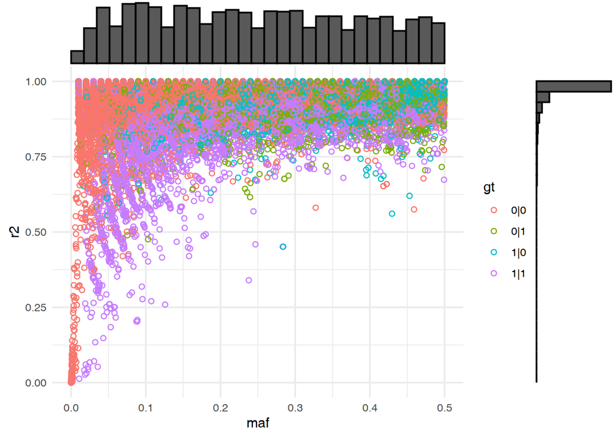

```r
id = "912014genome_Full_20140901163652"
vcf_path = "/fh/fast/peters_u/GECCO_Working/robert_working/nextflow/FH-PRS-tool-example/inputQC/23andMe_impute/vcf/"
vcf2 = read.vcfR(paste0(vcf_path, "chr1.imputed.vcf.gz"), verbose=F)
mid2 = makeMutID(vcf2)
vcf2 = vcf2[ mid2 %in% prssnps$newid,]
mid2 = makeMutID(vcf2)
vcf2@fix[,"ID"] = mid2
r22 = extract.info(vcf2, element="R2", as.numeric=T)
maf2 = extract.info(vcf2, element="MAF", as.numeric=T)
gt2 = extract.gt(vcf2, element = "GT")[,id]
ds2 = extract.gt(vcf2, element = "DS")[,id]

vstats = data.frame(maf=maf2, r2=r22, gt=gt2)
p = ggplot(vstats, aes(x=maf, y=r2, color=gt)) + geom_point(pch=1) + theme_minimal()
plot(ggMarginal(p, type = "histogram"))
```

```r
print(mean(r22))
```

```
## [1] 0.9694626
```

$Rsq$ estimates appear much higher with batch imputation. Hard to impute variants -e.g., low MAF - are of low quality/$Rsq$, as expected. Variants with MAF > 0.01 show a noticeably higher $Rsq$ than from single sample imputation. Mean $Rsq$ exceeds 0.96 for this sample and chromosome. Dosage correlation is investigated for the sample and chromosome with a hexplot:

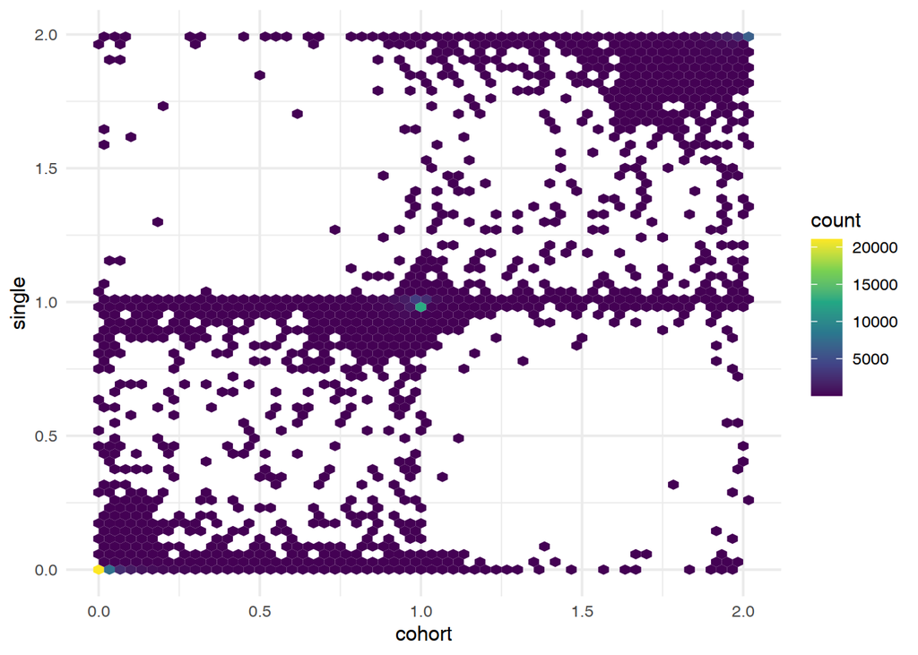

```r
dstats = data.frame(cohort=as.numeric(ds), single=as.numeric(ds2))
colnames(dstats) = c("cohort", "single")
rownames(dstats) = NULL
ggplot(dstats, aes(x=cohort, y=single)) + geom_hex(bins=60) + scale_fill_viridis_c() + theme_minimal()
```

```r
cor(dstats$cohort, dstats$single)
```

```
## [1] 0.9759294
```

```r
discordant_by_threshold <- function(x, y, threshold = 1) {
  diff <- abs(x - y)
  sum(diff > threshold)
}

d = discordant_by_threshold(dstats$cohort, dstats$single, threshold = 0.2)
print(d/nrow(dstats))
```

```
## [1] 0.07257192
```

There are sporadic discordant dosages with ~7% of SNPs where $\lvert dosage_{batch} - dosage_{single}\rvert > 0.2$

This is expected, we have previously observed this when comparing single sample imputed to batch imputed samples from the GenomeQuebec cohort.

We should check correlation of raw PRS of the the two sets (single sample vs batch).

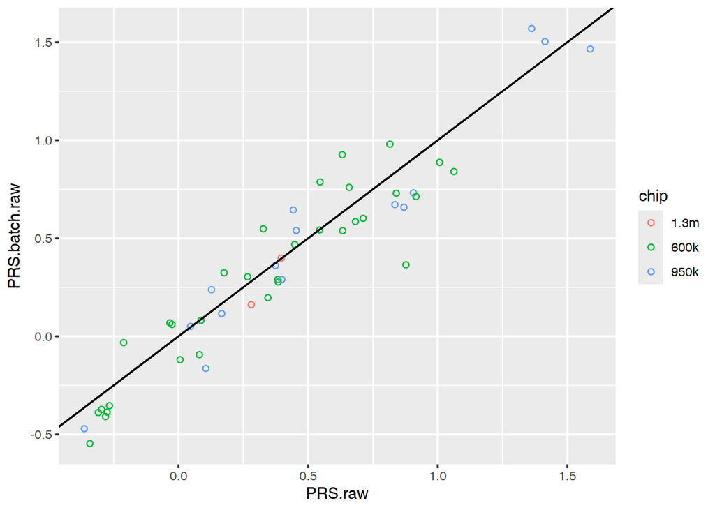

```r
# This has been pre-computed
vcf_path = "/fh/fast/peters_u/GECCO_Working/robert_working/nextflow/FH-PRS-tool-example/inputQC/23andMe_impute/vcf/"

loadBatchVcf = function(chr, vcf_path){

  vcf = fread(paste0(vcf_path, 'chr', chr,'.imputed.vcf.gz'),
              showProgress=F, nThread=1, data.table=FALSE)
  return(vcf)
}

#Pre-computed
#vcfs = mclapply(1:22, loadBatchVcf, vcf_path=vcf_path, mc.cores=16)

calc_prs = function(vcf, ids, prssnps_chr){

        idx = match(prssnps_chr$newid, paste0(vcf$ID,':',vcf$REF,':', vcf$ALT))
        tmp = vcf[idx,]
        scores = rep(NA, length(ids))
        for(i in 1:length(ids)){
                id = ids[i]
                tpp = tmp[,c(1:9, which(colnames(tmp) == id))]
                tp = str_split_fixed(tpp$FORMAT, ":", n=4)
                tp1 = str_split_fixed(tpp[,id], ":", n=4)
                idx1=which(tp[,1]=='DS')
                idx2=which(tp[,2]=='DS')
                idx3=which(tp[,3]=='DS')
                idx4=which(tp[,4]=='DS')
                fprs=rep(0,nrow(tp))

                if(length(idx1)!=0){
                        fprs[idx1]=as.numeric(tp1[idx1,1])
                }

                if(length(idx2)!=0){
                        fprs[idx2]=as.numeric(tp1[idx2,2])
                }

                if(length(idx3)!=0){
                        fprs[idx3]=as.numeric(tp1[idx3,3])
                }

                if(length(idx4)!=0){
                        fprs[idx4]=as.numeric(tp1[idx4,4])
                }

                scores[i] = as.numeric(as.numeric(fprs) %*% as.matrix(prssnps_chr$beta_grid4))
        }
        return(scores)
}

#Pre-computed
#scores = mclapply(1:22, function(chr) {calc_prs(vcfs[[chr]], ids, prssnps_chr=prssnps[prssnps$chr == chr, ])}, mc.cores=16)
#results$PRS.batch.raw = NA
#for(i in 1:nrow(results)){
#
#        results$PRS.batch.raw[i] = sum(unlist(lapply(scores, '[', i)))
#
#}

results = read.table("/fh/fast/peters_u/GECCO_Working/robert_working/nextflow/FH-PRS-tool-example/inputQC/23andMe_imputation_stats_w_batch_May8_2025.tsv",
                     header=T, sep='\t')

ggplot(results, aes(x=PRS.raw, y=PRS.batch.raw, color=chip)) + geom_point(pch=1) + geom_abline(slope=1, intercept=0)
```

```r
#Correlation of dosage
cor(results$PRS.raw , results$PRS.batch.raw)
```

```
## [1] 0.9515736
```

```r
r = results$PRS.raw - results$PRS.batch.raw

#SD by chip
tapply(r, results$chip, sd)
```

```
##       1.3m       600k       950k
## 0.08623034 0.16337927 0.14841494
```

```r
#Bin missingness
results$missing.cat = ifelse(results$pct.NA < 0.015, 'low', ifelse(results$pct.NA < 0.025, 'medium', 'high'))

#SD by missingness
tapply(r, results$missing.cat, sd)
```

```
##      high       low    medium
## 0.2182796 0.1207260 0.1448789
```

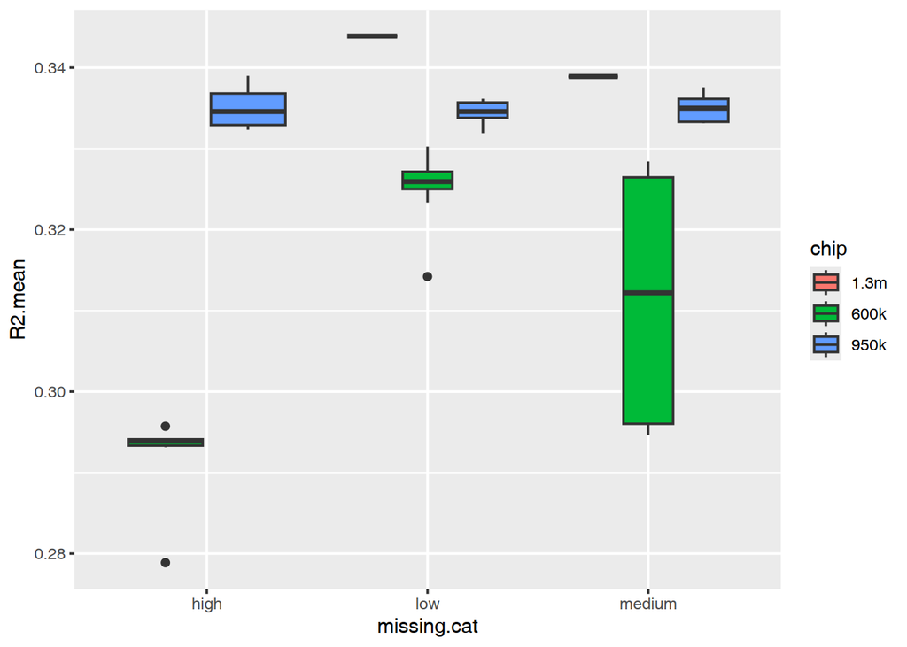

```r
#Boxplot by chip and missingness

ggplot(results, aes(x=missing.cat, y=R2.mean, fill=chip)) + geom_boxplot()
```